# PART-A

• DOMAIN: Botanical Research

• CONTEXT: University X is currently undergoing some research involving understanding the characteristics of plant and plant seedlings at various stages of growth. They already have have invested on curating sample images. They require an automation which can create a classifier capable of determining a plant's species from a photo.

• DATA DESCRIPTION: The dataset comprises of images from 12 plant species. Source: https://www.kaggle.com/c/plant-seedlings-classification/data.

• PROJECT OBJECTIVE: To create a classifier capable of determining a plant's species from a photo

## Part A - Q1 A - Extract ‘plant-seedlings-classification.zip’ into new folder (unzipped) using python.

```python
import numpy as np
import pandas as pd
import matplotlib.pyplot as plt
import seaborn as sns
```

```python
from zipfile import ZipFile
```

```python
#extracting file in zip folder
file  = "plant-seedlings-classification.zip"
with ZipFile(file,'r') as zip:
  zip.extractall(path='C:/Users/Admin/Downloads/COMPUTER_VISION/Project_work/project_1/')
```

## Part A - Q1 B - Map the images from train folder with train labels to form a DataFrame.

```python
import os
import cv2
dataset = 'C:/Users/Admin/Downloads/COMPUTER_VISION/Project_work/project_1/plant-seedlings-classification/train/'
```

```python
for i in os.listdir(dataset):
    print(i)
```

```
.DS_Store
Black-grass
Charlock
Cleavers
Common Chickweed
Common wheat
Fat Hen
Loose Silky-bent
Maize
Scentless Mayweed
Shepherds Purse
Small-flowered Cranesbill
Sugar beet
```

```python
x = []
y = []
labels = []
for i in os.listdir(dataset):
    if i != '.DS_Store':
        print(i)
        labels.append(i)
        for j in os.listdir(os.path.join(dataset,i)):
            im = cv2.imread(os.path.join(dataset,i,j))
            x.append(im)
            y.append(i)
```

```
Black-grass
Charlock
Cleavers
Common Chickweed
Common wheat
Fat Hen
Loose Silky-bent
Maize
Scentless Mayweed
Shepherds Purse
Small-flowered Cranesbill
Sugar beet
```

```python
print("The number of images are : " , len(x))
```

```
The number of images are :  4750
```

```python
print("The shape of images are :",x[0].shape)
```

```
The shape of images are : (196, 196, 3)
```

```python
for i in np.arange(1,5):
    print(x[i].shape)
```

```
(388, 388, 3)
(886, 886, 3)
(117, 117, 3)
(471, 471, 3)
```

- by seeing this every image has its own shape,we will convert that shape to fixed format

## C. Write a function that will select n random images and display images along with its species.

```python
def random_images(n):
    rand = np.random.randint(0,len(x),n)
    print(rand)
    plt.figure(figsize=(15,15))
    for i,j in enumerate(rand):
        plt.subplot(1,len(rand),i+1)
        plt.imshow(x[j])
        plt.title("{}".format(y[j]))
        plt.axis("off")
        plt.show()
```

```
[1478 3673  792 3034 3111]
```

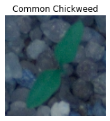

```python
random_images(5)
```

```python
def random_images_1(n):
    rand = np.random.randint(0,len(x),n)
    print(rand)
    for j in rand:
        print(x[j].shape)
```

```python
random_images_1(10)
```

```
[3412 3599 2993 1339 4739  281 3200 2761 4393  419]
(101, 101, 3)
(185, 185, 3)
(367, 367, 3)
(115, 115, 3)
(686, 686, 3)
(1046, 1046, 3)
(137, 137, 3)
(153, 153, 3)
(471, 471, 3)
(469, 469, 3)
```

```python
x[3120].shape
```

```
(65, 65, 3)
```

## 2. Data preprocessing

## A. Create X & Y from the DataFrame.

```python
X = np.array(x)
Y = np.array(y)
```

```python
X[0].shape,Y.shape
```

```
((196, 196, 3), (4750,))
```

## B. Encode labels of the images.

```python
# encoding labels
rep = dict()
count = 0
for i in labels:
    rep[i] = count
    count = count+1
```

```python
rep
```

```
{'Black-grass': 0,
 'Charlock': 1,
 'Cleavers': 2,
 'Common Chickweed': 3,
 'Common wheat': 4,
 'Fat Hen': 5,
 'Loose Silky-bent': 6,
 'Maize': 7,
 'Scentless Mayweed': 8,
 'Shepherds Purse': 9,
 'Small-flowered Cranesbill': 10,
 'Sugar beet': 11}
```

```python
Y_df = pd.DataFrame(Y)
```

```python
Y_df.value_counts()
```

```
Loose Silky-bent             654
Common Chickweed             611
Scentless Mayweed            516
Small-flowered Cranesbill    496
Fat Hen                      475
Charlock                     390
Sugar beet                   385
Cleavers                     287
Black-grass                  263
Shepherds Purse              231
Common wheat                 221
Maize                        221
dtype: int64
```

- The classes are imbalanced

```python
Y_new_lab = Y_df.replace(rep)
```

```python
# to encode classes to neural netwok acceptable format
import tensorflow as tf
from tensorflow.keras.utils import to_categorical
```

```python
Y_new_lab = to_categorical(Y_new_lab,12)
Y_new_lab
```

```
array([[1., 0., 0., ..., 0., 0., 0.],
       [1., 0., 0., ..., 0., 0., 0.],
       [1., 0., 0., ..., 0., 0., 0.],
       ...,
       [0., 0., 0., ..., 0., 0., 1.],
       [0., 0., 0., ..., 0., 0., 1.],
       [0., 0., 0., ..., 0., 0., 1.]], dtype=float32)
```

```python
Y_new_lab.shape
```

```
(4750, 12)
```

## C. Unify shape of all the images.

- Since we have different shapes of images, we resizing the images as follows

```python
X_1 = []
for m in X:
    im = cv2.resize(m,(128,128))
    X_1.append(im)
for i in np.arange(0,5):
    print(X_1[i].shape)
```

```
(128, 128, 3)
(128, 128, 3)
(128, 128, 3)
(128, 128, 3)
(128, 128, 3)
```

## D. Normalise all the images.

```python
X = np.array(X_1)
```

```python
X[0]
```

[output not shown]

```python
X = X/255.0      #normalizing the values
```

```python
X[0]
```

[output not shown]

## 3. Model training

## A. Split the data into train and test data.

```python
from sklearn.model_selection import train_test_split
```

```python
x_train,x_test,y_train,y_test = train_test_split(X,Y_new_lab,test_size=0.2,random_state=42)
x_train.shape,y_train.shape,x_test.shape,y_test.shape
```

```
((3800, 128, 128, 3), (3800, 12), (950, 128, 128, 3), (950, 12))
```

## B. Create new CNN architecture to train the model.

## C. Train the model on train data and validate on test data.

```python
import tensorflow as tf
from tensorflow.keras.models import Sequential
from tensorflow.keras.layers import Convolution2D,MaxPooling2D,BatchNormalization,Dropout,Dense
from tensorflow.keras.layers import Flatten,GlobalMaxPool2D
from tensorflow.keras.losses import CategoricalCrossentropy as cc
from tensorflow.keras.optimizers import Adam,RMSprop
from tensorflow.keras.callbacks import EarlyStopping

es = EarlyStopping(patience=3)
```

```python
#creating CNN model
model = Sequential()

#1st convolution layer
model.add(BatchNormalization(input_shape = (128,128,3)))
model.add(Convolution2D(filters=32,kernel_size=(3,3),activation='relu',input_shape=(128,128,3)))
#maxpooling
model.add(MaxPooling2D(pool_size=(2,2)))

#adding flatten
model.add(Flatten())

#adding ann layer
model.add(Dense(units=32,activation='relu'))
#final layer
model.add(Dense(units=12,activation='softmax'))
```

```python
#compiling the model
model.compile(loss=tf.keras.losses.categorical_crossentropy,optimizer = 'rmsprop',metrics=['accuracy'])
```

```python
model.summary()
```

```
Model: "sequential"
_________________________________________________________________
 Layer (type)                Output Shape              Param #
=================================================================
 batch_normalization (BatchN  (None, 128, 128, 3)      12
 ormalization)

 conv2d (Conv2D)             (None, 126, 126, 32)      896

 max_pooling2d (MaxPooling2D  (None, 63, 63, 32)       0
 )

 flatten (Flatten)           (None, 127008)            0

 dense (Dense)               (None, 32)                4064288

 dense_1 (Dense)             (None, 12)                396

=================================================================
Total params: 4,065,592
Trainable params: 4,065,586
Non-trainable params: 6
_________________________________________________________________
```

```python
hist = model.fit(x_train,y_train,validation_split=0.2,epochs=15,callbacks=es)
```

```python
from sklearn.metrics import classification_report,confusion_matrix
```

```python
def loss_plot(history):
    plt.plot(history.history['loss'])
    plt.plot(history.history['val_loss'])
    plt.title('Model Loss')
    plt.ylabel('loss')
    plt.xlabel('epoch')
    plt.legend(['training','validation'],loc='best')
    plt.show()
def accuracy_plot(history):
    plt.plot(history.history['accuracy'])
    plt.plot(history.history['val_accuracy'])
    plt.title('Model accuracy')
    plt.ylabel('Accuracy')
    plt.xlabel('epoch')
    plt.legend(['training','validation'],loc='best')
    plt.show()
```

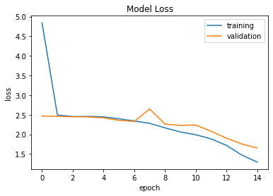

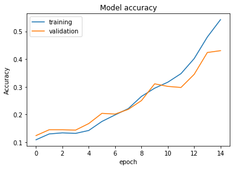

```
(None, None)
```

```python
loss_plot(hist),accuracy_plot(hist)
```

```python
model.evaluate(x_test,y_test)
```

```
[1.6310549974441528, 0.4263157844543457]
```

- our model is not training well,we add little complexity and check

```python
del model
del hist
```

```python
from tensorflow.keras.layers import Conv2D,InputLayer
```

```python
model_final = Sequential()

model_final.add(BatchNormalization(input_shape=(128,128,3)))

model_final.add(Conv2D(filters=32,kernel_size=(3,3),activation='relu',padding='valid',input_shape=(128,128,3),kernel_initializer = 'he_normal',kernel_regularizer='l2'))
model_final.add(MaxPooling2D(pool_size=(2,2)))

model_final.add(Conv2D(filters=64,kernel_size=(3,3),activation='relu',padding='valid',kernel_initializer = 'he_normal',kernel_regularizer='l2'))
model_final.add(MaxPooling2D(pool_size=(2,2)))

model_final.add(Conv2D(filters=128,kernel_size=(3,3),activation='relu',padding='valid'))
model_final.add(MaxPooling2D(pool_size=(2,2)))

model_final.add(Conv2D(filters=256,kernel_size=(3,3),activation='relu',padding='valid'))
model_final.add(MaxPooling2D(pool_size=(2,2)))

model_final.add(Conv2D(filters=512,kernel_size=(3,3),activation='relu',padding='valid'))
model_final.add(MaxPooling2D(pool_size=(2,2)))

model_final.add(Flatten())

model_final.add(Dropout(0.8))

model_final.add(Dense(128,activation='relu'))

model_final.add(Dropout(0.2))

model_final.add(Dense(units=12,activation='softmax'))

model_final.compile(loss=tf.keras.losses.categorical_crossentropy,optimizer = 'adam',metrics=['accuracy'])

model_final.summary()
```

```
Model: "sequential_1"
_________________________________________________________________
 Layer (type)                Output Shape              Param #
=================================================================
 batch_normalization_1 (Batc  (None, 128, 128, 3)      12
 hNormalization)

 conv2d_1 (Conv2D)           (None, 126, 126, 32)      896

 max_pooling2d_1 (MaxPooling  (None, 63, 63, 32)       0
 2D)

 conv2d_2 (Conv2D)           (None, 61, 61, 64)        18496

 max_pooling2d_2 (MaxPooling  (None, 30, 30, 64)       0
 2D)

 conv2d_3 (Conv2D)           (None, 28, 28, 128)       73856

 max_pooling2d_3 (MaxPooling  (None, 14, 14, 128)      0
 2D)

 conv2d_4 (Conv2D)           (None, 12, 12, 256)       295168

 max_pooling2d_4 (MaxPooling  (None, 6, 6, 256)        0
 2D)

 conv2d_5 (Conv2D)           (None, 4, 4, 512)         1180160

 max_pooling2d_5 (MaxPooling  (None, 2, 2, 512)        0
 2D)

 flatten_1 (Flatten)         (None, 2048)              0

 dropout (Dropout)           (None, 2048)              0

 dense_2 (Dense)             (None, 128)               262272

 dropout_1 (Dropout)         (None, 128)               0

 dense_3 (Dense)             (None, 12)                1548

=================================================================
Total params: 1,832,408
Trainable params: 1,832,402
Non-trainable params: 6
_________________________________________________________________
```

```python
es = EarlyStopping(patience=5)
```

```python
np.random.seed(42)
import random
random.seed(42)
tf.random.set_seed(42)
```

```python
hist_final = model_final.fit(x_train,y_train,validation_split=0.2,epochs=40,callbacks=es)
```

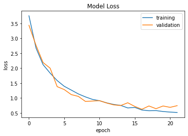

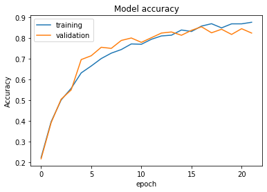

```
(None, None)
```

```python
loss_plot(hist_final),accuracy_plot(hist_final)
```

```python
model_final.evaluate(x_test,y_test)
```

```
[0.6165993809700012, 0.8284210562705994]
```

```python
y_pred = model_final.predict(x_test)
print(y_pred[0])
```

```
[4.6618231e-07 4.3738158e-03 2.1422903e-04 2.5416516e-02 1.0781696e-05
 1.1352678e-04 6.9541788e-06 2.3767442e-04 1.8526307e-01 7.8377759e-01
 2.2866561e-04 3.5669628e-04]
```

```python
y_tst = []
for i in y_test:
    tst = np.argmax(i)
    y_tst.append(tst)
y_prd = []
for j in y_pred:
    prd = np.argmax(j)
    y_prd.append(prd)
```

```python
print(classification_report(y_tst,y_prd))
```

```
              precision    recall  f1-score   support

           0       0.44      0.06      0.11        67
           1       0.97      0.84      0.90        79
           2       0.98      0.75      0.85        57
           3       0.83      0.99      0.91       125
           4       0.84      0.77      0.81        35
           5       0.78      0.94      0.85        80
           6       0.67      0.95      0.79       140
           7       0.95      0.85      0.90        46
           8       0.79      0.89      0.84        94
           9       0.73      0.64      0.68        42
          10       0.99      0.88      0.93       101
          11       0.95      0.90      0.93        84

    accuracy                           0.83       950
   macro avg       0.83      0.79      0.79       950
weighted avg       0.82      0.83      0.81       950
```

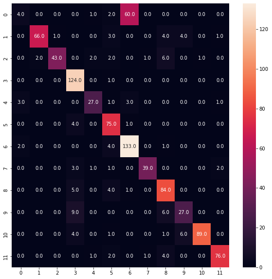

```python
cm = confusion_matrix(y_tst,y_prd)
plt.figure(figsize=(10,10))
sns.heatmap(cm,annot = True,fmt='.1f')
```

## D. Select a random image and print actual label and predicted label for the same.

```python
label = pd.DataFrame(labels,index=np.arange(0,12))
label
```

|  | 0 |
| --- | --- |
| 0 | Black-grass |
| 1 | Charlock |
| 2 | Cleavers |
| 3 | Common Chickweed |
| 4 | Common wheat |
| 5 | Fat Hen |
| 6 | Loose Silky-bent |
| 7 | Maize |
| 8 | Scentless Mayweed |
| 9 | Shepherds Purse |
| 10 | Small-flowered Cranesbill |
| 11 | Sugar beet |

```python
def random_model_check(img):
    plt.figure(figsize=(8,8))
    plt.imshow(x_test[img])
    img_label = np.argmax(y_test[img])
    print("The original label for the image is : " , img_label )
    print("the label is :",label[0][img_label])
    print("*-"*40)
    pred_label = model_final.predict(x_test[img].reshape(1,128,128,3))
    print("*-"*40)
    model_label = np.argmax(y_test[img])
    print("The model predicted label as : ",model_label)
    print("the label is :",label[0][model_label])
```

[output not shown]

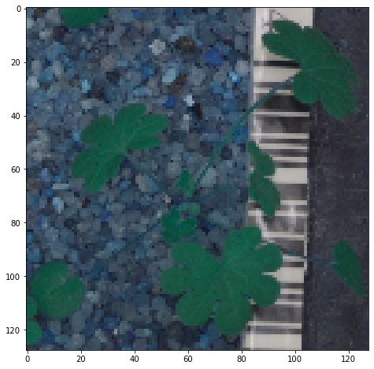

```python
random_model_check(155)
```

# Part -B

• DOMAIN: Botanical Research

• CONTEXT: University X is currently undergoing some research involving understanding the characteristics of flowers. They already have have invested on curating sample images. They require an automation which can create a classifier capable of determining a flower’s species from a photo.

• DATA DESCRIPTION: The dataset comprises of images from 17 plant species.

• PROJECT OBJECTIVE: To experiment with various approaches to train an image classifier to predict type of flower from the image

# 1. Import and Understand the data

## A. Import and read oxflower17 dataset from tflearn and split into X and Y while loading.

```python
!pip install tflearn
import tflearn
from tflearn import datasets
```

```
WARNING:tensorflow:From C:\Users\Admin\anaconda3\lib\site-packages\tensorflow\python\compat\v2_compat.py:107: disable_resource_variables (from tensorflow.python.ops.variable_scope) is deprecated and will be removed in a future version.
Instructions for updating:
non-resource variables are not supported in the long term
curses is not supported on this machine (please install/reinstall curses for an optimal experience)
```

```python
from tflearn.datasets import oxflower17

#load dataset

X , Y = oxflower17.load_data()
```

```python
print("The shape of dataset is :"
      ,(X.shape,Y.shape))
```

```
The shape of dataset is : ((1360, 224, 224, 3), (1360,))
```

## B. Print Number of images and shape of the images.

```python
print("The number of images are : " , len(X))
print("The shape of images are :",X.shape)
```

```
The number of images are :  1360
The shape of images are : (1360, 224, 224, 3)
```

## C. Print count of each class from y.

```python
Y_df = pd.DataFrame(Y)
#count of each class
Y_df.value_counts().sort_index()
```

```
0     80
1     80
2     80
3     80
4     80
5     80
6     80
7     80
8     80
9     80
10    80
11    80
12    80
13    80
14    80
15    80
16    80
dtype: int64
```

- There are 17 classes are present and each class is balanced

# 2. Image Exploration & Transformation

## A. Display 5 random images.

```python
def display_imgs(n):
    rand = np.random.randint(0,len(X),n)
    print(rand)
    plt.figure(figsize=(15,15))
    for i,j in enumerate(rand):
        plt.subplot(1,len(rand),i+1)
        plt.imshow(X[j])
        plt.title(Y[j])
        plt.axis('off')
```

```
[1126  860 1294 1130 1095]
```

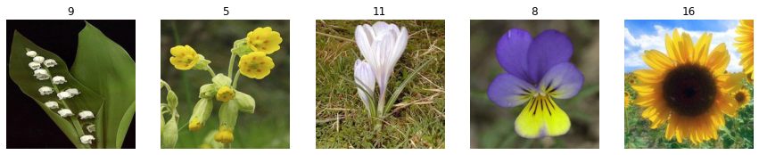

```python
display_imgs(5)
```

## B. Select any image from the dataset and assign it to a variable.

```python
image = X[131]
```

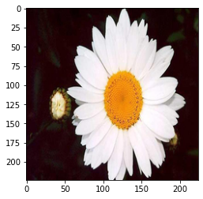

```python
plt.imshow(image);
```

## C. Transform the image into grayscale format and display the same.

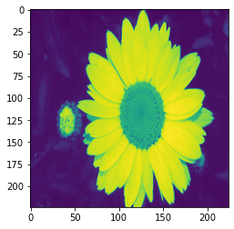

```python
import cv2,random
# Original Image
plt.imshow(image)

# Gray Image
gray_image = cv2.cvtColor(image, cv2.COLOR_RGB2GRAY)

plt.imshow(gray_image);
```

## D. Apply a filter to sharpen the image and display the image before and after sharpening.

```
Clipping input data to the valid range for imshow with RGB data ([0..1] for floats or [0..255] for integers).
```

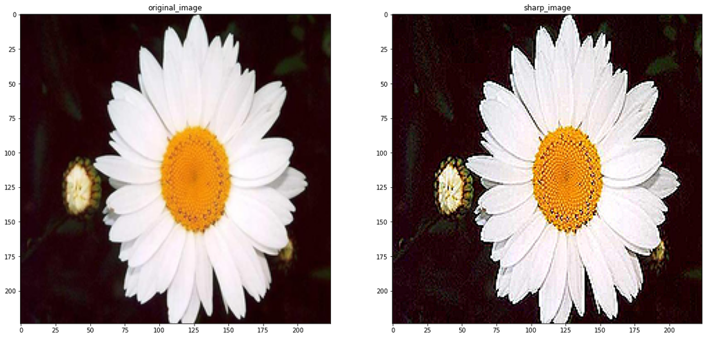

```python
# Sharp Image
sharp_filter = np.array([[0,-1,0],
                        [-1,5,-1],
                        [0,-1,0]])

sharp_img = cv2.filter2D(image,kernel=sharp_filter,ddepth=-1)

img_title = ['original_image', 'sharp_image']

plt.figure(figsize=(20,20))
for i,img in enumerate([image,sharp_img]):
    plt.subplot(1,2,i+1)
    plt.title(img_title[i])
    plt.imshow(img,cmap='gray');
```

## E. Apply a filter to blur the image and display the image before and after blur.

```python
# Blur Image
blur_img = cv2.GaussianBlur(image,ksize=(5,5),sigmaX=0,sigmaY=0)
```

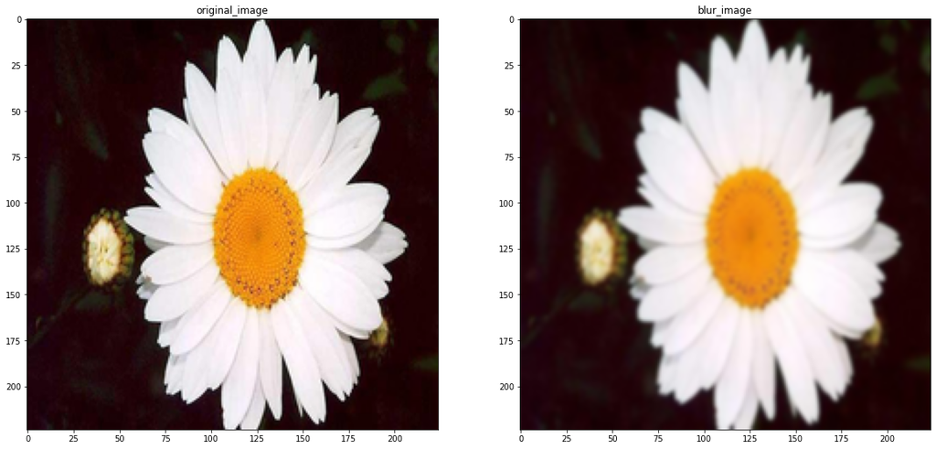

```python
img_title = ['original_image', 'blur_image']

plt.figure(figsize=(20,20))
for i,img in enumerate([image,blur_img]):
    plt.subplot(1,2,i+1)
    plt.title(img_title[i])
    plt.imshow(img,cmap='gray');
```

## F. Display all the 4 images from above questions besides each other to observe the difference.

```
Clipping input data to the valid range for imshow with RGB data ([0..1] for floats or [0..255] for integers).
```

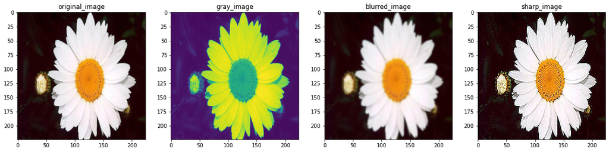

```python
img_title = ['original_image', 'gray_image', 'blurred_image', 'sharp_image']

plt.figure(figsize=(20,20))
for i,img in enumerate([image, gray_image, blur_img, sharp_img]):
    plt.subplot(1,4,i+1)
    plt.title(img_title[i])
    plt.imshow(img)
```

# 3. Model training and Tuning

## A. Split the data into train and test with 80:20 proportion.

```python
from sklearn.model_selection import train_test_split
x_train,x_test,y_train,y_test = train_test_split(X,Y,test_size=0.2,random_state=42)
x_train.shape,y_train.shape,x_test.shape,y_test.shape
```

```
((1088, 224, 224, 3), (1088,), (272, 224, 224, 3), (272,))
```

```python
x_train_1 = []
for x in x_train:
    im = cv2.resize(x,(128,128))
    x_train_1.append(im)
```

```python
x_train_1[0].shape
```

```
(128, 128, 3)
```

```python
x_test_1 = []
for x in x_test:
    im = cv2.resize(x,(128,128))
    x_test_1.append(im)
```

## B. Train a model using any Supervised Learning algorithm and share performance metrics on test data.

```python
x_train = np.array(x_train_1)
x_test  = np.array(x_test_1)
```

```python
x_train_ml = x_train.reshape(len(x_train),128*128*3)
x_test_ml = x_test.reshape(len(x_test),128*128*3)
```

```python
x_train_ml.shape,x_test_ml.shape
```

```
((1088, 49152), (272, 49152))
```

- since we have more number of features then compared with number of records,its undergoes into curse of dimensionality
- to avoid curse of dimensionality we can apply PCA method to reduce number of features

```python
#PCA transformation

from sklearn.decomposition import PCA

pca = PCA(0.99)

pca.fit(x_train_ml)
x_train_pca = pca.transform(x_train_ml)
x_test_pca = pca.transform(x_test_ml)
```

```python
x_train_pca.shape,x_test_pca.shape
```

```
((1088, 877), (272, 877))
```

```python
from sklearn.svm import SVC
```

```python
# SVM - Model

SVM = SVC()
SVM.fit(x_train_pca, y_train)

#Training score
SVM_Accuracy=SVM.score(x_train_pca, y_train)
print("Train Accuracy : ", SVM_Accuracy)

#Testing score
SVM_Accuracy=SVM.score(x_test_pca, y_test)
print("Test Accuracy : ", SVM_Accuracy)
```

```
Train Accuracy :  0.9411764705882353
Test Accuracy :  0.4632352941176471
```

```python
pca_1 = PCA(0.90)

pca_1.fit(x_train_ml)
x_train_pca = pca_1.transform(x_train_ml)
x_test_pca = pca_1.transform(x_test_ml)

x_train_pca.shape,x_test_pca.shape
```

```
((1088, 359), (272, 359))
```

```python
SVM1 = SVC()
SVM1.fit(x_train_pca, y_train)

SVM_Accuracy=SVM1.score(x_train_pca, y_train)
print("Train Accuracy : ", SVM_Accuracy)

SVM_Accuracy=SVM1.score(x_test_pca, y_test)
print("Test Accuracy : ", SVM_Accuracy)
```

```
Train Accuracy :  0.8988970588235294
Test Accuracy :  0.48161764705882354
```

## C. Train a model using Neural Network and share performance metrics on test data.

```python
# converts target classes to one hot encoding

from tensorflow.keras.utils import to_categorical
y_train_cat = to_categorical(y_train,17)
y_test_cat = to_categorical(y_test,17)
```

```python
print(y_train_cat)

print("The shape of target classes are : ", y_train_cat.shape)
```

```
[[0. 0. 0. ... 0. 0. 0.]
 [0. 1. 0. ... 0. 0. 0.]
 [0. 0. 0. ... 0. 0. 0.]
 ...
 [0. 0. 0. ... 0. 0. 0.]
 [0. 0. 0. ... 0. 0. 0.]
 [0. 0. 0. ... 0. 0. 0.]]
The shape of target classes are :  (1088, 17)
```

```python
# ANN Model
model = Sequential()

#input layer
model.add(BatchNormalization(input_shape=(128*128*3,)))

#1st hidden layer
model.add(Dense(512,activation='relu'))
model.add(BatchNormalization())
model.add(Dropout(0.8))

#2nd hidden layer
model.add(Dense(256,activation='relu'))
model.add(BatchNormalization())

#3rd hidden layer
model.add(Dense(180,activation='relu'))
model.add(BatchNormalization())

#4th,5th,6th hidden layers
model.add(Dense(128,activation='relu'))
model.add(Dense(64,activation='relu'))
model.add(Dense(32,activation='relu'))
model.add(BatchNormalization())


model.add(Dense(17,activation='softmax'))
```

```
WARNING:tensorflow:From C:\Users\Admin\anaconda3\lib\site-packages\keras\layers\normalization\batch_normalization.py:561: _colocate_with (from tensorflow.python.framework.ops) is deprecated and will be removed in a future version.
Instructions for updating:
Colocations handled automatically by placer.
```

```python
model.compile(loss=tf.keras.losses.categorical_crossentropy,optimizer = 'adam',metrics = ['accuracy'])
```

```python
hist = model.fit(x_train_ml,y_train_cat,validation_split=0.2,epochs=30)
```

```
Train on 870 samples, validate on 218 samples
```

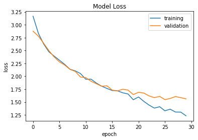

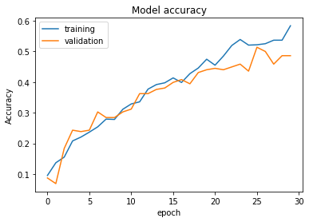

```
(None, None)
```

```python
def accuracy_plot(history):
    plt.plot(history.history['acc'])
    plt.plot(history.history['val_acc'])
    plt.title('Model accuracy')
    plt.ylabel('Accuracy')
    plt.xlabel('epoch')
    plt.legend(['training','validation'],loc='best')
    plt.show()
loss_plot(hist),accuracy_plot(hist)
```

```python
model.evaluate(x_test_ml,y_test_cat)
```

```
[1.70426826617297, 0.4632353]
```

- model not trained well

```python
y_pred = model.predict(x_test_ml)
y_tst = []
for i in y_test_cat:
    tst = np.argmax(i)
    y_tst.append(tst)
y_prd = []
for j in y_pred:
    prd = np.argmax(j)
    y_prd.append(prd)
```

```
              precision    recall  f1-score   support

           0       0.42      0.31      0.36        16
           1       0.33      0.47      0.39        15
           2       0.54      0.35      0.42        20
           3       0.25      0.60      0.35        10
           4       0.53      0.40      0.46        20
           5       0.29      0.44      0.35        16
           6       0.33      0.12      0.18        16
           7       0.36      0.29      0.32        17
           8       0.82      0.47      0.60        19
           9       1.00      0.47      0.64        17
          10       0.62      0.73      0.67        11
          11       0.53      0.69      0.60        13
          12       0.60      0.50      0.55        18
          13       0.45      0.62      0.53        16
          14       0.28      0.53      0.36        15
          15       0.41      0.58      0.48        12
          16       1.00      0.52      0.69        21

    accuracy                           0.46       272
   macro avg       0.52      0.48      0.47       272
weighted avg       0.54      0.46      0.47       272
```

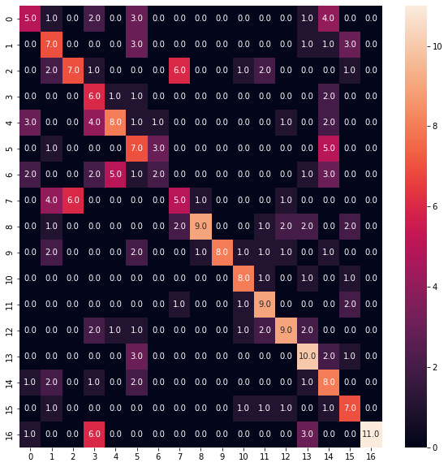

```python
print(classification_report(y_tst,y_prd))
cm = confusion_matrix(y_tst,y_prd)
plt.figure(figsize=(10,10))
sns.heatmap(cm,annot = True,fmt='.1f')
```

```python
del model
del hist
```

## D. Train a model using a basic CNN and share performance metrics on test data.

```python
np.random.seed(42)
import random
random.seed(5)
tf.random.set_seed(5)
```

```python
#CNN Model

model = Sequential()

#input layer with Batchnormalization
model.add(BatchNormalization(input_shape=(128,128,3,)))

#1st convolution layer
model.add(Conv2D(48,kernel_size=(3,3),padding='valid',activation='relu',input_shape=(128,128,3),kernel_initializer = 'he_normal',kernel_regularizer = 'l2'))
model.add(MaxPooling2D(pool_size=(2,2)))

#batchnormalization
model.add(BatchNormalization())

#2nd convolution layer
model.add(Conv2D(64,kernel_size=(3,3),padding='valid',activation='relu',kernel_initializer = 'he_normal',kernel_regularizer = 'l2'))
model.add(MaxPooling2D(pool_size=(2,2)))

model.add(BatchNormalization())

#3rd convolution layer
model.add(Conv2D(128,kernel_size=(3,3),padding='valid',activation='relu',kernel_initializer = 'he_normal'))
model.add(MaxPooling2D(pool_size=(2,2)))

model.add(BatchNormalization())

#4th convolution layer
model.add(Conv2D(64,kernel_size=(3,3),padding='valid',activation='relu',kernel_initializer = 'he_normal'))
model.add(MaxPooling2D(pool_size=(2,2)))

model.add(BatchNormalization())

#5th convolution layer
model.add(Conv2D(128,kernel_size=(3,3),padding='valid',activation='relu',kernel_initializer = 'he_normal'))
model.add(MaxPooling2D(pool_size=(2,2)))

model.add(BatchNormalization())

#adding global maxpool layer
model.add(GlobalMaxPool2D())

#flatten layer
model.add(Flatten())

#adding dropout layer to avoid overfitting
model.add(Dropout(0.8))
model.add(Dense(756,activation='relu',kernel_initializer = 'he_normal'))
model.add(Dropout(0.2))

#output layer
model.add(Dense(17,activation='softmax'))

#compile the model
model.compile(loss='categorical_crossentropy',optimizer = 'adam', metrics = ['accuracy'])

#fit the model to our training
hist = model.fit(x_train,y_train_cat,validation_split = 0.2,epochs=75)
```

```
Train on 870 samples, validate on 218 samples
```

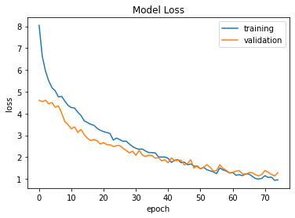

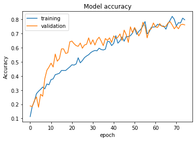

```
(None, None)
```

```python
loss_plot(hist),accuracy_plot(hist)
```

```python
#evaluating on testing data

model.evaluate(x_test,y_test_cat)
```

```
[1.2456849638153524, 0.7610294]
```

```python
y_pred = model.predict(x_test)
y_tst = []
for i in y_test_cat:
    tst = np.argmax(i)
    y_tst.append(tst)
y_prd = []
for j in y_pred:
    prd = np.argmax(j)
    y_prd.append(prd)
```

```
              precision    recall  f1-score   support

           0       0.58      0.69      0.63        16
           1       0.61      0.73      0.67        15
           2       0.95      0.90      0.92        20
           3       0.42      0.80      0.55        10
           4       0.89      0.40      0.55        20
           5       0.58      0.88      0.70        16
           6       0.76      0.81      0.79        16
           7       0.94      0.94      0.94        17
           8       1.00      0.79      0.88        19
           9       0.80      0.71      0.75        17
          10       0.89      0.73      0.80        11
          11       0.79      0.85      0.81        13
          12       0.86      0.67      0.75        18
          13       0.88      0.88      0.88        16
          14       0.62      0.33      0.43        15
          15       0.80      1.00      0.89        12
          16       0.79      0.90      0.84        21

    accuracy                           0.76       272
   macro avg       0.77      0.76      0.75       272
weighted avg       0.79      0.76      0.76       272
```

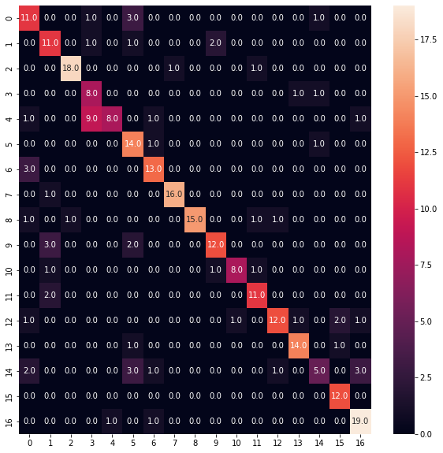

```python
print(classification_report(y_tst,y_prd))
cm = confusion_matrix(y_tst,y_prd)
plt.figure(figsize=(10,10))
sns.heatmap(cm,annot = True,fmt='.1f')
```

## E. Predict the class/label of image ‘Prediction.jpg’ using best performing model and share predicted label

```python
# loading image
Image_name = 'Prediction.jpg'
```

```python
img = cv2.imread(Image_name)
print("The shape of image is ",img.shape)
```

```
The shape of image is  (224, 224, 3)
```

```python
print(img)
```

[output not shown]

```python
img = cv2.resize(img,(128,128))  #resizing the image
img = img/255.0                  #scaling the image to 0 to 1
print("The shape of image after resizing ",img.shape)
```

```
The shape of image after resizing  (128, 128, 3)
```

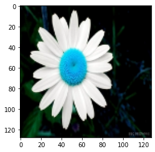

```python
plt.imshow(img)
```

```python
y_pred = model.predict(x_test[0].reshape(1,128,128,3))
y_pred
```

```
array([[8.0216887e-06, 2.0728972e-04, 9.5615658e-05, 7.8692324e-07,
        1.2492241e-07, 1.2674090e-07, 1.8188990e-05, 9.9897975e-01,
        3.7444825e-04, 1.0124856e-05, 2.3926048e-06, 1.2024992e-04,
        1.7618676e-04, 4.3027594e-08, 3.3945517e-07, 6.2373083e-06,
        1.3478914e-08]], dtype=float32)
```

```python
y_pred_img = model.predict(img.reshape(1,128,128,3))
print("The predictions are : ",np.round(y_pred_img,3))
print("\n")
print("*"*20)
print("The label for the image is ",np.argmax(y_pred_img))
```

```
The predictions are :  [[0.    0.    0.971 0.    0.    0.    0.    0.026 0.    0.001 0.    0.
  0.    0.    0.    0.001 0.   ]]


The label for the image is  2
```